# Risk Factor Analysis

## Outcome Variable

**Outcome Variable:** ever_stunted

## Predictor Variables

**Intervention Variable:** feducyrs

**Adjustment Set:**

- arm
- W_mage
- meducyrs
- W_mhtcm
- W_gagebrth
- W_birthwt
- W_birthlen
- single
- delta_W_mage
- delta_meducyrs
- delta_W_mhtcm
- delta_W_gagebrth
- delta_W_birthwt
- delta_W_birthlen
- delta_single

## Stratifying Variables

The analysis was stratified on these variable(s):

- agecat
- studyid
- country

## Data Summary

| agecat | studyid | country | feducyrs | ever_stunted | n_cell | n |
| --- | --- | --- | --- | --- | --- | --- |
| 0-6 months | ki0047075b-MAL-ED | BANGLADESH | Q4 | 0 | 46 | 149 |
| 0-6 months | ki0047075b-MAL-ED | BANGLADESH | Q4 | 1 | 8 | 149 |
| 0-6 months | ki0047075b-MAL-ED | BANGLADESH | Q1 | 0 | 25 | 149 |
| 0-6 months | ki0047075b-MAL-ED | BANGLADESH | Q1 | 1 | 6 | 149 |
| 0-6 months | ki0047075b-MAL-ED | BANGLADESH | Q2 | 0 | 6 | 149 |
| 0-6 months | ki0047075b-MAL-ED | BANGLADESH | Q2 | 1 | 3 | 149 |
| 0-6 months | ki0047075b-MAL-ED | BANGLADESH | Q3 | 0 | 45 | 149 |
| 0-6 months | ki0047075b-MAL-ED | BANGLADESH | Q3 | 1 | 10 | 149 |
| 0-6 months | ki0047075b-MAL-ED | INDIA | Q4 | 0 | 36 | 147 |
| 0-6 months | ki0047075b-MAL-ED | INDIA | Q4 | 1 | 8 | 147 |
| 0-6 months | ki0047075b-MAL-ED | INDIA | Q1 | 0 | 24 | 147 |
| 0-6 months | ki0047075b-MAL-ED | INDIA | Q1 | 1 | 1 | 147 |
| 0-6 months | ki0047075b-MAL-ED | INDIA | Q2 | 0 | 39 | 147 |
| 0-6 months | ki0047075b-MAL-ED | INDIA | Q2 | 1 | 6 | 147 |
| 0-6 months | ki0047075b-MAL-ED | INDIA | Q3 | 0 | 28 | 147 |
| 0-6 months | ki0047075b-MAL-ED | INDIA | Q3 | 1 | 5 | 147 |
| 0-6 months | ki0047075b-MAL-ED | NEPAL | Q4 | 0 | 37 | 98 |
| 0-6 months | ki0047075b-MAL-ED | NEPAL | Q4 | 1 | 5 | 98 |
| 0-6 months | ki0047075b-MAL-ED | NEPAL | Q1 | 0 | 21 | 98 |
| 0-6 months | ki0047075b-MAL-ED | NEPAL | Q1 | 1 | 3 | 98 |
| 0-6 months | ki0047075b-MAL-ED | NEPAL | Q2 | 0 | 19 | 98 |
| 0-6 months | ki0047075b-MAL-ED | NEPAL | Q2 | 1 | 6 | 98 |
| 0-6 months | ki0047075b-MAL-ED | NEPAL | Q3 | 0 | 6 | 98 |
| 0-6 months | ki0047075b-MAL-ED | NEPAL | Q3 | 1 | 1 | 98 |
| 0-6 months | ki0047075b-MAL-ED | PERU | Q4 | 0 | 109 | 250 |
| 0-6 months | ki0047075b-MAL-ED | PERU | Q4 | 1 | 11 | 250 |
| 0-6 months | ki0047075b-MAL-ED | PERU | Q1 | 0 | 40 | 250 |
| 0-6 months | ki0047075b-MAL-ED | PERU | Q1 | 1 | 11 | 250 |
| 0-6 months | ki0047075b-MAL-ED | PERU | Q2 | 0 | 59 | 250 |
| 0-6 months | ki0047075b-MAL-ED | PERU | Q2 | 1 | 7 | 250 |

[output cut: 446 more lines]

The following strata were considered:

- agecat: 0-24 months, studyid: ki0047075b-MAL-ED, country: BANGLADESH
- agecat: 0-24 months, studyid: ki0047075b-MAL-ED, country: INDIA
- agecat: 0-24 months, studyid: ki0047075b-MAL-ED, country: NEPAL
- agecat: 0-24 months, studyid: ki0047075b-MAL-ED, country: PERU
- agecat: 0-24 months, studyid: ki0047075b-MAL-ED, country: SOUTH AFRICA
- agecat: 0-24 months, studyid: ki0047075b-MAL-ED, country: TANZANIA, UNITED REPUBLIC OF
- agecat: 0-24 months, studyid: ki1000304b-SAS-CompFeed, country: INDIA
- agecat: 0-24 months, studyid: ki1000304b-SAS-FoodSuppl, country: INDIA
- agecat: 0-24 months, studyid: ki1017093b-PROVIDE, country: BANGLADESH
- agecat: 0-24 months, studyid: ki1017093c-NIH-Crypto, country: BANGLADESH
- agecat: 0-24 months, studyid: ki1066203-TanzaniaChild2, country: TANZANIA, UNITED REPUBLIC OF
- agecat: 0-24 months, studyid: ki1113344-GMS-Nepal, country: NEPAL
- agecat: 0-24 months, studyid: ki1119695-PROBIT, country: BELARUS
- agecat: 0-24 months, studyid: ki1126311-ZVITAMBO, country: ZIMBABWE
- agecat: 0-24 months, studyid: ki1135781-COHORTS, country: GUATEMALA
- agecat: 0-24 months, studyid: ki1135781-COHORTS, country: INDIA
- agecat: 0-24 months, studyid: ki1135781-COHORTS, country: PHILIPPINES
- agecat: 0-24 months, studyid: ki1148112-LCNI-5, country: MALAWI
- agecat: 0-24 months, studyid: kiGH5241-JiVitA-3, country: BANGLADESH
- agecat: 0-24 months, studyid: kiGH5241-JiVitA-4, country: BANGLADESH
- agecat: 0-6 months, studyid: ki0047075b-MAL-ED, country: BANGLADESH
- agecat: 0-6 months, studyid: ki0047075b-MAL-ED, country: INDIA
- agecat: 0-6 months, studyid: ki0047075b-MAL-ED, country: NEPAL
- agecat: 0-6 months, studyid: ki0047075b-MAL-ED, country: PERU
- agecat: 0-6 months, studyid: ki0047075b-MAL-ED, country: SOUTH AFRICA
- agecat: 0-6 months, studyid: ki0047075b-MAL-ED, country: TANZANIA, UNITED REPUBLIC OF
- agecat: 0-6 months, studyid: ki1000304b-SAS-CompFeed, country: INDIA
- agecat: 0-6 months, studyid: ki1000304b-SAS-FoodSuppl, country: INDIA
- agecat: 0-6 months, studyid: ki1017093b-PROVIDE, country: BANGLADESH
- agecat: 0-6 months, studyid: ki1017093c-NIH-Crypto, country: BANGLADESH
- agecat: 0-6 months, studyid: ki1066203-TanzaniaChild2, country: TANZANIA, UNITED REPUBLIC OF
- agecat: 0-6 months, studyid: ki1113344-GMS-Nepal, country: NEPAL
- agecat: 0-6 months, studyid: ki1119695-PROBIT, country: BELARUS
- agecat: 0-6 months, studyid: ki1126311-ZVITAMBO, country: ZIMBABWE
- agecat: 0-6 months, studyid: ki1135781-COHORTS, country: GUATEMALA
- agecat: 0-6 months, studyid: ki1135781-COHORTS, country: INDIA
- agecat: 0-6 months, studyid: ki1135781-COHORTS, country: PHILIPPINES
- agecat: 0-6 months, studyid: ki1148112-LCNI-5, country: MALAWI
- agecat: 0-6 months, studyid: kiGH5241-JiVitA-3, country: BANGLADESH
- agecat: 0-6 months, studyid: kiGH5241-JiVitA-4, country: BANGLADESH
- agecat: 6-24 months, studyid: ki0047075b-MAL-ED, country: BANGLADESH
- agecat: 6-24 months, studyid: ki0047075b-MAL-ED, country: INDIA
- agecat: 6-24 months, studyid: ki0047075b-MAL-ED, country: NEPAL
- agecat: 6-24 months, studyid: ki0047075b-MAL-ED, country: PERU
- agecat: 6-24 months, studyid: ki0047075b-MAL-ED, country: SOUTH AFRICA
- agecat: 6-24 months, studyid: ki0047075b-MAL-ED, country: TANZANIA, UNITED REPUBLIC OF
- agecat: 6-24 months, studyid: ki1000304b-SAS-CompFeed, country: INDIA
- agecat: 6-24 months, studyid: ki1000304b-SAS-FoodSuppl, country: INDIA
- agecat: 6-24 months, studyid: ki1017093b-PROVIDE, country: BANGLADESH
- agecat: 6-24 months, studyid: ki1017093c-NIH-Crypto, country: BANGLADESH
- agecat: 6-24 months, studyid: ki1066203-TanzaniaChild2, country: TANZANIA, UNITED REPUBLIC OF
- agecat: 6-24 months, studyid: ki1113344-GMS-Nepal, country: NEPAL
- agecat: 6-24 months, studyid: ki1119695-PROBIT, country: BELARUS
- agecat: 6-24 months, studyid: ki1126311-ZVITAMBO, country: ZIMBABWE
- agecat: 6-24 months, studyid: ki1135781-COHORTS, country: GUATEMALA
- agecat: 6-24 months, studyid: ki1135781-COHORTS, country: INDIA
- agecat: 6-24 months, studyid: ki1135781-COHORTS, country: PHILIPPINES
- agecat: 6-24 months, studyid: ki1148112-LCNI-5, country: MALAWI
- agecat: 6-24 months, studyid: kiGH5241-JiVitA-3, country: BANGLADESH
- agecat: 6-24 months, studyid: kiGH5241-JiVitA-4, country: BANGLADESH

### Dropped Strata

Some strata were dropped due to rare outcomes:

- agecat: 0-6 months, studyid: ki0047075b-MAL-ED, country: BANGLADESH
- agecat: 0-6 months, studyid: ki0047075b-MAL-ED, country: INDIA
- agecat: 0-6 months, studyid: ki0047075b-MAL-ED, country: NEPAL
- agecat: 0-6 months, studyid: ki0047075b-MAL-ED, country: PERU
- agecat: 0-6 months, studyid: ki0047075b-MAL-ED, country: SOUTH AFRICA
- agecat: 0-6 months, studyid: ki0047075b-MAL-ED, country: TANZANIA, UNITED REPUBLIC OF
- agecat: 0-6 months, studyid: ki1017093b-PROVIDE, country: BANGLADESH
- agecat: 0-6 months, studyid: ki1066203-TanzaniaChild2, country: TANZANIA, UNITED REPUBLIC OF
- agecat: 0-6 months, studyid: ki1119695-PROBIT, country: BELARUS
- agecat: 0-6 months, studyid: ki1135781-COHORTS, country: GUATEMALA
- agecat: 6-24 months, studyid: ki0047075b-MAL-ED, country: BANGLADESH
- agecat: 6-24 months, studyid: ki0047075b-MAL-ED, country: NEPAL
- agecat: 6-24 months, studyid: ki0047075b-MAL-ED, country: PERU
- agecat: 6-24 months, studyid: ki0047075b-MAL-ED, country: SOUTH AFRICA
- agecat: 6-24 months, studyid: ki0047075b-MAL-ED, country: TANZANIA, UNITED REPUBLIC OF
- agecat: 6-24 months, studyid: ki1017093b-PROVIDE, country: BANGLADESH
- agecat: 6-24 months, studyid: ki1066203-TanzaniaChild2, country: TANZANIA, UNITED REPUBLIC OF
- agecat: 6-24 months, studyid: ki1119695-PROBIT, country: BELARUS
- agecat: 6-24 months, studyid: ki1135781-COHORTS, country: GUATEMALA
- agecat: 0-24 months, studyid: ki0047075b-MAL-ED, country: BANGLADESH
- agecat: 0-24 months, studyid: ki0047075b-MAL-ED, country: NEPAL
- agecat: 0-24 months, studyid: ki0047075b-MAL-ED, country: PERU
- agecat: 0-24 months, studyid: ki0047075b-MAL-ED, country: TANZANIA, UNITED REPUBLIC OF
- agecat: 0-24 months, studyid: ki1017093b-PROVIDE, country: BANGLADESH
- agecat: 0-24 months, studyid: ki1066203-TanzaniaChild2, country: TANZANIA, UNITED REPUBLIC OF
- agecat: 0-24 months, studyid: ki1135781-COHORTS, country: GUATEMALA

## Methods Detail

We’re interested in the causal parameters $E[Y_a]$ for all values of $a \in \mathcal{A}$. These parameters represent the mean outcome if, possibly contrary to fact, we intervened to set all units to have $A=a$. Under the randomization and positivity assumptions, these are identified by the statistical parameters $\psi_a=E_W[E_{Y|A,W}(Y|A=a,W)]$. In addition, we’re interested in the mean of $Y$, $E[Y]$ under no intervention (the observed mean). We will estimate these parameters by using SuperLearner to fit the relevant likelihood factors – $E_{Y|A,W}(Y|A=a,W)$ and $p(A=a|W)$, and then updating our likelihood fit using a joint TMLE.

For unadjusted analyses ($W=\{\}$), initial likelihoods were estimated using Lrnr_glm to estimate the simple $E(Y|A)$ and Lrnr_mean to estimate $p(A)$. For adjusted analyses, a small library containing Lrnr_glmnet, Lrnr_xgboost, and Lrnr_mean was used.

Having estimated these parameters, we will then use the delta method to estimate relative risks and attributable risks relative to a prespecified baseline level of $A$.

```
##         ever_stunted
## feducyrs   0
##       Q4 359
##       Q1 176
##       Q2 163
##       Q3 463
```

# Results Detail

## Results Plots

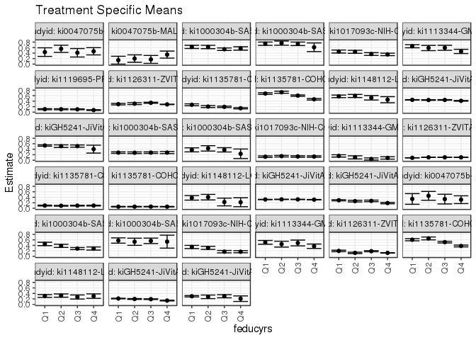

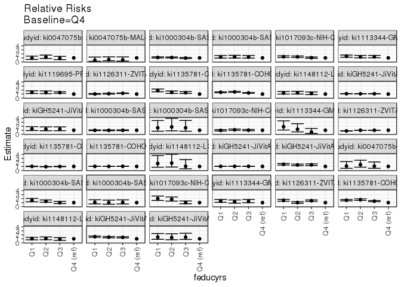

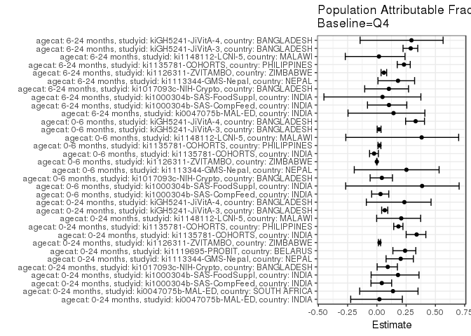

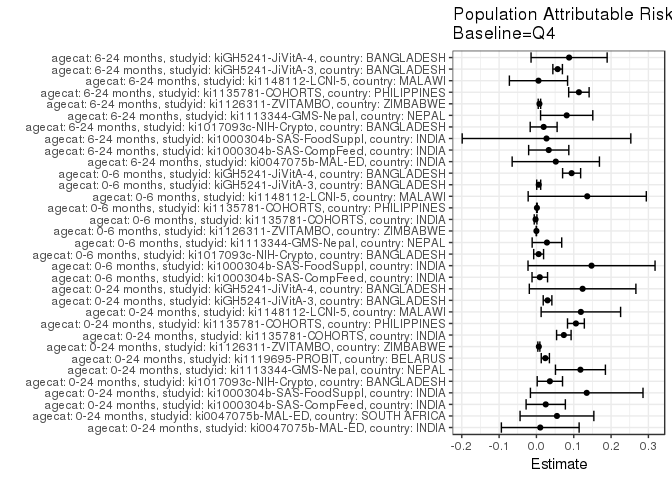

## Results Table

### Parameter: TSM

| agecat | studyid | country | intervention_level | baseline_level | estimate | ci_lower | ci_upper |
| --- | --- | --- | --- | --- | --- | --- | --- |
| 0-24 months | ki0047075b-MAL-ED | INDIA | Q4 | NA | 0.4659572 | 0.3347478 | 0.5971665 |
| 0-24 months | ki0047075b-MAL-ED | INDIA | Q1 | NA | 0.4359471 | 0.2797403 | 0.5921539 |
| 0-24 months | ki0047075b-MAL-ED | INDIA | Q2 | NA | 0.5557594 | 0.4252615 | 0.6862574 |
| 0-24 months | ki0047075b-MAL-ED | INDIA | Q3 | NA | 0.4116437 | 0.2575827 | 0.5657046 |
| 0-24 months | ki0047075b-MAL-ED | SOUTH AFRICA | Q4 | NA | 0.3450016 | 0.2171198 | 0.4728834 |
| 0-24 months | ki0047075b-MAL-ED | SOUTH AFRICA | Q1 | NA | 0.1416725 | -0.0016322 | 0.2849772 |
| 0-24 months | ki0047075b-MAL-ED | SOUTH AFRICA | Q2 | NA | 0.2010129 | 0.0655246 | 0.3365012 |
| 0-24 months | ki0047075b-MAL-ED | SOUTH AFRICA | Q3 | NA | 0.1699062 | 0.0262486 | 0.3135637 |
| 0-24 months | ki1000304b-SAS-CompFeed | INDIA | Q4 | NA | 0.5692048 | 0.5074922 | 0.6309173 |
| 0-24 months | ki1000304b-SAS-CompFeed | INDIA | Q1 | NA | 0.6258419 | 0.5675230 | 0.6841608 |
| 0-24 months | ki1000304b-SAS-CompFeed | INDIA | Q2 | NA | 0.6218956 | 0.5603704 | 0.6834208 |
| 0-24 months | ki1000304b-SAS-CompFeed | INDIA | Q3 | NA | 0.5411669 | 0.4953720 | 0.5869617 |
| 0-24 months | ki1000304b-SAS-FoodSuppl | INDIA | Q4 | NA | 0.6116890 | 0.4545915 | 0.7687864 |
| 0-24 months | ki1000304b-SAS-FoodSuppl | INDIA | Q1 | NA | 0.7418493 | 0.6813997 | 0.8022989 |
| 0-24 months | ki1000304b-SAS-FoodSuppl | INDIA | Q2 | NA | 0.7629439 | 0.6869635 | 0.8389243 |
| 0-24 months | ki1000304b-SAS-FoodSuppl | INDIA | Q3 | NA | 0.7379689 | 0.6737984 | 0.8021394 |
| 0-24 months | ki1017093c-NIH-Crypto | BANGLADESH | Q4 | NA | 0.3518756 | 0.3077211 | 0.3960300 |
| 0-24 months | ki1017093c-NIH-Crypto | BANGLADESH | Q1 | NA | 0.4570380 | 0.4020841 | 0.5119919 |
| 0-24 months | ki1017093c-NIH-Crypto | BANGLADESH | Q2 | NA | 0.4472903 | 0.3932993 | 0.5012813 |
| 0-24 months | ki1017093c-NIH-Crypto | BANGLADESH | Q3 | NA | 0.3659419 | 0.3157890 | 0.4160948 |
| 0-24 months | ki1113344-GMS-Nepal | NEPAL | Q4 | NA | 0.4611250 | 0.3839509 | 0.5382992 |
| 0-24 months | ki1113344-GMS-Nepal | NEPAL | Q1 | NA | 0.6495679 | 0.5929053 | 0.7062305 |
| 0-24 months | ki1113344-GMS-Nepal | NEPAL | Q2 | NA | 0.5847668 | 0.4889082 | 0.6806254 |
| 0-24 months | ki1113344-GMS-Nepal | NEPAL | Q3 | NA | 0.5929277 | 0.5017017 | 0.6841537 |
| 0-24 months | ki1119695-PROBIT | BELARUS | Q4 | NA | 0.0751428 | 0.0609448 | 0.0893407 |
| 0-24 months | ki1119695-PROBIT | BELARUS | Q1 | NA | 0.1071903 | 0.0890631 | 0.1253175 |
| 0-24 months | ki1119695-PROBIT | BELARUS | Q2 | NA | 0.1053108 | 0.0865570 | 0.1240646 |
| 0-24 months | ki1119695-PROBIT | BELARUS | Q3 | NA | 0.1025614 | 0.0865234 | 0.1185994 |
| 0-24 months | ki1126311-ZVITAMBO | ZIMBABWE | Q4 | NA | 0.2830937 | 0.2751942 | 0.2909932 |
| 0-24 months | ki1126311-ZVITAMBO | ZIMBABWE | Q1 | NA | 0.2917206 | 0.2641156 | 0.3193256 |

[output cut: 102 more lines]

### Parameter: E(Y)

| agecat | studyid | country | intervention_level | baseline_level | estimate | ci_lower | ci_upper |
| --- | --- | --- | --- | --- | --- | --- | --- |
| 0-24 months | ki0047075b-MAL-ED | INDIA | NA | NA | 0.4761905 | 0.3951786 | 0.5572024 |
| 0-24 months | ki0047075b-MAL-ED | SOUTH AFRICA | NA | NA | 0.4000000 | 0.3080312 | 0.4919688 |
| 0-24 months | ki1000304b-SAS-CompFeed | INDIA | NA | NA | 0.5941176 | 0.5531511 | 0.6350842 |
| 0-24 months | ki1000304b-SAS-FoodSuppl | INDIA | NA | NA | 0.7464115 | 0.7046540 | 0.7881689 |
| 0-24 months | ki1017093c-NIH-Crypto | BANGLADESH | NA | NA | 0.3878628 | 0.3531521 | 0.4225735 |
| 0-24 months | ki1113344-GMS-Nepal | NEPAL | NA | NA | 0.5790349 | 0.5395303 | 0.6185396 |
| 0-24 months | ki1119695-PROBIT | BELARUS | NA | NA | 0.0989947 | 0.0831753 | 0.1148141 |
| 0-24 months | ki1126311-ZVITAMBO | ZIMBABWE | NA | NA | 0.2895640 | 0.2819669 | 0.2971611 |
| 0-24 months | ki1135781-COHORTS | INDIA | NA | NA | 0.2163096 | 0.1950882 | 0.2375310 |
| 0-24 months | ki1135781-COHORTS | PHILIPPINES | NA | NA | 0.5743056 | 0.5562443 | 0.5923668 |
| 0-24 months | ki1148112-LCNI-5 | MALAWI | NA | NA | 0.5719557 | 0.5379231 | 0.6059884 |
| 0-24 months | kiGH5241-JiVitA-3 | BANGLADESH | NA | NA | 0.4414466 | 0.4338889 | 0.4490043 |
| 0-24 months | kiGH5241-JiVitA-4 | BANGLADESH | NA | NA | 0.5269656 | 0.5048164 | 0.5491148 |
| 0-6 months | ki1000304b-SAS-CompFeed | INDIA | NA | NA | 0.2881467 | 0.2614090 | 0.3148844 |
| 0-6 months | ki1000304b-SAS-FoodSuppl | INDIA | NA | NA | 0.3822115 | 0.3354600 | 0.4289631 |
| 0-6 months | ki1017093c-NIH-Crypto | BANGLADESH | NA | NA | 0.1385224 | 0.1139141 | 0.1631308 |
| 0-6 months | ki1113344-GMS-Nepal | NEPAL | NA | NA | 0.1114809 | 0.0862979 | 0.1366638 |
| 0-6 months | ki1126311-ZVITAMBO | ZIMBABWE | NA | NA | 0.1048051 | 0.0996708 | 0.1099394 |
| 0-6 months | ki1135781-COHORTS | INDIA | NA | NA | 0.0957072 | 0.0804059 | 0.1110086 |
| 0-6 months | ki1135781-COHORTS | PHILIPPINES | NA | NA | 0.0604167 | 0.0517136 | 0.0691198 |
| 0-6 months | ki1148112-LCNI-5 | MALAWI | NA | NA | 0.3558052 | 0.2982716 | 0.4133389 |
| 0-6 months | kiGH5241-JiVitA-3 | BANGLADESH | NA | NA | 0.3202185 | 0.3133886 | 0.3270484 |
| 0-6 months | kiGH5241-JiVitA-4 | BANGLADESH | NA | NA | 0.2848297 | 0.2655018 | 0.3041577 |
| 6-24 months | ki0047075b-MAL-ED | INDIA | NA | NA | 0.3644068 | 0.2772025 | 0.4516111 |
| 6-24 months | ki1000304b-SAS-CompFeed | INDIA | NA | NA | 0.3187954 | 0.2885259 | 0.3490649 |
| 6-24 months | ki1000304b-SAS-FoodSuppl | INDIA | NA | NA | 0.5619469 | 0.4971181 | 0.6267757 |
| 6-24 months | ki1017093c-NIH-Crypto | BANGLADESH | NA | NA | 0.1887097 | 0.1578857 | 0.2195336 |
| 6-24 months | ki1113344-GMS-Nepal | NEPAL | NA | NA | 0.4488518 | 0.4042636 | 0.4934400 |
| 6-24 months | ki1126311-ZVITAMBO | ZIMBABWE | NA | NA | 0.1343481 | 0.1273279 | 0.1413683 |
| 6-24 months | ki1135781-COHORTS | PHILIPPINES | NA | NA | 0.4911779 | 0.4697758 | 0.5125799 |
| 6-24 months | ki1148112-LCNI-5 | MALAWI | NA | NA | 0.3084922 | 0.2707734 | 0.3462110 |
| 6-24 months | kiGH5241-JiVitA-3 | BANGLADESH | NA | NA | 0.1965318 | 0.1884248 | 0.2046388 |
| 6-24 months | kiGH5241-JiVitA-4 | BANGLADESH | NA | NA | 0.2962963 | 0.2730810 | 0.3195116 |

### Parameter: RR

| agecat | studyid | country | intervention_level | baseline_level | estimate | ci_lower | ci_upper |
| --- | --- | --- | --- | --- | --- | --- | --- |
| 0-24 months | ki0047075b-MAL-ED | INDIA | Q4 | Q4 | 1.0000000 | 1.0000000 | 1.0000000 |
| 0-24 months | ki0047075b-MAL-ED | INDIA | Q1 | Q4 | 0.9355948 | 0.6081857 | 1.4392605 |
| 0-24 months | ki0047075b-MAL-ED | INDIA | Q2 | Q4 | 1.1927264 | 0.8420698 | 1.6894042 |
| 0-24 months | ki0047075b-MAL-ED | INDIA | Q3 | Q4 | 0.8834367 | 0.5633645 | 1.3853562 |
| 0-24 months | ki0047075b-MAL-ED | SOUTH AFRICA | Q4 | Q4 | 1.0000000 | 1.0000000 | 1.0000000 |
| 0-24 months | ki0047075b-MAL-ED | SOUTH AFRICA | Q1 | Q4 | 0.4106431 | 0.1394650 | 1.2091046 |
| 0-24 months | ki0047075b-MAL-ED | SOUTH AFRICA | Q2 | Q4 | 0.5826435 | 0.2699248 | 1.2576591 |
| 0-24 months | ki0047075b-MAL-ED | SOUTH AFRICA | Q3 | Q4 | 0.4924794 | 0.1955188 | 1.2404738 |
| 0-24 months | ki1000304b-SAS-CompFeed | INDIA | Q4 | Q4 | 1.0000000 | 1.0000000 | 1.0000000 |
| 0-24 months | ki1000304b-SAS-CompFeed | INDIA | Q1 | Q4 | 1.0995022 | 0.9613451 | 1.2575142 |
| 0-24 months | ki1000304b-SAS-CompFeed | INDIA | Q2 | Q4 | 1.0925692 | 0.9753051 | 1.2239322 |
| 0-24 months | ki1000304b-SAS-CompFeed | INDIA | Q3 | Q4 | 0.9507419 | 0.8285680 | 1.0909307 |
| 0-24 months | ki1000304b-SAS-FoodSuppl | INDIA | Q4 | Q4 | 1.0000000 | 1.0000000 | 1.0000000 |
| 0-24 months | ki1000304b-SAS-FoodSuppl | INDIA | Q1 | Q4 | 1.2127884 | 0.9290722 | 1.5831447 |
| 0-24 months | ki1000304b-SAS-FoodSuppl | INDIA | Q2 | Q4 | 1.2472742 | 0.9492485 | 1.6388679 |
| 0-24 months | ki1000304b-SAS-FoodSuppl | INDIA | Q3 | Q4 | 1.2064447 | 0.9235530 | 1.5759883 |
| 0-24 months | ki1017093c-NIH-Crypto | BANGLADESH | Q4 | Q4 | 1.0000000 | 1.0000000 | 1.0000000 |
| 0-24 months | ki1017093c-NIH-Crypto | BANGLADESH | Q1 | Q4 | 1.2988625 | 1.1159890 | 1.5117030 |
| 0-24 months | ki1017093c-NIH-Crypto | BANGLADESH | Q2 | Q4 | 1.2711605 | 1.0934447 | 1.4777602 |
| 0-24 months | ki1017093c-NIH-Crypto | BANGLADESH | Q3 | Q4 | 1.0399752 | 0.8882046 | 1.2176794 |
| 0-24 months | ki1113344-GMS-Nepal | NEPAL | Q4 | Q4 | 1.0000000 | 1.0000000 | 1.0000000 |
| 0-24 months | ki1113344-GMS-Nepal | NEPAL | Q1 | Q4 | 1.4086589 | 1.1663368 | 1.7013267 |
| 0-24 months | ki1113344-GMS-Nepal | NEPAL | Q2 | Q4 | 1.2681306 | 1.0036687 | 1.6022769 |
| 0-24 months | ki1113344-GMS-Nepal | NEPAL | Q3 | Q4 | 1.2858284 | 1.0251443 | 1.6128019 |
| 0-24 months | ki1119695-PROBIT | BELARUS | Q4 | Q4 | 1.0000000 | 1.0000000 | 1.0000000 |
| 0-24 months | ki1119695-PROBIT | BELARUS | Q1 | Q4 | 1.4264886 | 1.1311492 | 1.7989402 |
| 0-24 months | ki1119695-PROBIT | BELARUS | Q2 | Q4 | 1.4014763 | 1.1111868 | 1.7676017 |
| 0-24 months | ki1119695-PROBIT | BELARUS | Q3 | Q4 | 1.3648879 | 1.1790942 | 1.5799578 |
| 0-24 months | ki1126311-ZVITAMBO | ZIMBABWE | Q4 | Q4 | 1.0000000 | 1.0000000 | 1.0000000 |
| 0-24 months | ki1126311-ZVITAMBO | ZIMBABWE | Q1 | Q4 | 1.0304739 | 0.9361061 | 1.1343549 |

[output cut: 102 more lines]

### Parameter: PAR

| agecat | studyid | country | intervention_level | baseline_level | estimate | ci_lower | ci_upper |
| --- | --- | --- | --- | --- | --- | --- | --- |
| 0-24 months | ki0047075b-MAL-ED | INDIA | Q4 | NA | 0.0102333 | -0.0939241 | 0.1143907 |
| 0-24 months | ki0047075b-MAL-ED | SOUTH AFRICA | Q4 | NA | 0.0549984 | -0.0438363 | 0.1538331 |
| 0-24 months | ki1000304b-SAS-CompFeed | INDIA | Q4 | NA | 0.0249129 | -0.0276927 | 0.0775185 |
| 0-24 months | ki1000304b-SAS-FoodSuppl | INDIA | Q4 | NA | 0.1347225 | -0.0161049 | 0.2855499 |
| 0-24 months | ki1017093c-NIH-Crypto | BANGLADESH | Q4 | NA | 0.0359872 | 0.0020454 | 0.0699290 |
| 0-24 months | ki1113344-GMS-Nepal | NEPAL | Q4 | NA | 0.1179099 | 0.0510128 | 0.1848069 |
| 0-24 months | ki1119695-PROBIT | BELARUS | Q4 | NA | 0.0238520 | 0.0129250 | 0.0347790 |
| 0-24 months | ki1126311-ZVITAMBO | ZIMBABWE | Q4 | NA | 0.0064703 | 0.0037261 | 0.0092145 |
| 0-24 months | ki1135781-COHORTS | INDIA | Q4 | NA | 0.0734474 | 0.0540001 | 0.0928948 |
| 0-24 months | ki1135781-COHORTS | PHILIPPINES | Q4 | NA | 0.1058060 | 0.0832604 | 0.1283515 |
| 0-24 months | ki1148112-LCNI-5 | MALAWI | Q4 | NA | 0.1190581 | 0.0126102 | 0.2255059 |
| 0-24 months | kiGH5241-JiVitA-3 | BANGLADESH | Q4 | NA | 0.0297769 | 0.0181827 | 0.0413712 |
| 0-24 months | kiGH5241-JiVitA-4 | BANGLADESH | Q4 | NA | 0.1237157 | -0.0190530 | 0.2664844 |
| 0-6 months | ki1000304b-SAS-CompFeed | INDIA | Q4 | NA | 0.0090005 | -0.0118029 | 0.0298040 |
| 0-6 months | ki1000304b-SAS-FoodSuppl | INDIA | Q4 | NA | 0.1476249 | -0.0225487 | 0.3177986 |
| 0-6 months | ki1017093c-NIH-Crypto | BANGLADESH | Q4 | NA | 0.0058941 | -0.0073601 | 0.0191482 |
| 0-6 months | ki1113344-GMS-Nepal | NEPAL | Q4 | NA | 0.0281411 | -0.0114470 | 0.0677291 |
| 0-6 months | ki1126311-ZVITAMBO | ZIMBABWE | Q4 | NA | -0.0000523 | -0.0002686 | 0.0001640 |
| 0-6 months | ki1135781-COHORTS | INDIA | Q4 | NA | -0.0023066 | -0.0058820 | 0.0012688 |
| 0-6 months | ki1135781-COHORTS | PHILIPPINES | Q4 | NA | 0.0013303 | 0.0005556 | 0.0021051 |
| 0-6 months | ki1148112-LCNI-5 | MALAWI | Q4 | NA | 0.1361181 | -0.0221568 | 0.2943930 |
| 0-6 months | kiGH5241-JiVitA-3 | BANGLADESH | Q4 | NA | 0.0060994 | 0.0007921 | 0.0114068 |
| 0-6 months | kiGH5241-JiVitA-4 | BANGLADESH | Q4 | NA | 0.0942677 | 0.0701145 | 0.1184209 |
| 6-24 months | ki0047075b-MAL-ED | INDIA | Q4 | NA | 0.0518799 | -0.0650419 | 0.1688017 |
| 6-24 months | ki1000304b-SAS-CompFeed | INDIA | Q4 | NA | 0.0329399 | -0.0208596 | 0.0867394 |
| 6-24 months | ki1000304b-SAS-FoodSuppl | INDIA | Q4 | NA | 0.0269695 | -0.1989279 | 0.2528669 |
| 6-24 months | ki1017093c-NIH-Crypto | BANGLADESH | Q4 | NA | 0.0193599 | -0.0167010 | 0.0554208 |
| 6-24 months | ki1113344-GMS-Nepal | NEPAL | Q4 | NA | 0.0810370 | 0.0110876 | 0.1509864 |
| 6-24 months | ki1126311-ZVITAMBO | ZIMBABWE | Q4 | NA | 0.0080569 | 0.0048086 | 0.0113051 |
| 6-24 months | ki1135781-COHORTS | PHILIPPINES | Q4 | NA | 0.1137664 | 0.0863835 | 0.1411492 |
| 6-24 months | ki1148112-LCNI-5 | MALAWI | Q4 | NA | 0.0054921 | -0.0724773 | 0.0834615 |
| 6-24 months | kiGH5241-JiVitA-3 | BANGLADESH | Q4 | NA | 0.0568150 | 0.0439934 | 0.0696365 |
| 6-24 months | kiGH5241-JiVitA-4 | BANGLADESH | Q4 | NA | 0.0875255 | -0.0144017 | 0.1894527 |

### Parameter: PAF

| agecat | studyid | country | intervention_level | baseline_level | estimate | ci_lower | ci_upper |
| --- | --- | --- | --- | --- | --- | --- | --- |
| 0-24 months | ki0047075b-MAL-ED | INDIA | Q4 | NA | 0.0214899 | -0.2236008 | 0.2174883 |
| 0-24 months | ki0047075b-MAL-ED | SOUTH AFRICA | Q4 | NA | 0.1374961 | -0.1469724 | 0.3514116 |
| 0-24 months | ki1000304b-SAS-CompFeed | INDIA | Q4 | NA | 0.0419326 | -0.0504143 | 0.1261608 |
| 0-24 months | ki1000304b-SAS-FoodSuppl | INDIA | Q4 | NA | 0.1804936 | -0.0491838 | 0.3598922 |
| 0-24 months | ki1017093c-NIH-Crypto | BANGLADESH | Q4 | NA | 0.0927834 | 0.0020668 | 0.1752534 |
| 0-24 months | ki1113344-GMS-Nepal | NEPAL | Q4 | NA | 0.2036317 | 0.0785781 | 0.3117134 |
| 0-24 months | ki1119695-PROBIT | BELARUS | Q4 | NA | 0.2409419 | 0.1367420 | 0.3325643 |
| 0-24 months | ki1126311-ZVITAMBO | ZIMBABWE | Q4 | NA | 0.0223451 | 0.0128442 | 0.0317546 |
| 0-24 months | ki1135781-COHORTS | INDIA | Q4 | NA | 0.3395477 | 0.2500851 | 0.4183377 |
| 0-24 months | ki1135781-COHORTS | PHILIPPINES | Q4 | NA | 0.1842329 | 0.1439844 | 0.2225890 |
| 0-24 months | ki1148112-LCNI-5 | MALAWI | Q4 | NA | 0.2081596 | -0.0018300 | 0.3741341 |
| 0-24 months | kiGH5241-JiVitA-3 | BANGLADESH | Q4 | NA | 0.0674531 | 0.0409553 | 0.0932187 |
| 0-24 months | kiGH5241-JiVitA-4 | BANGLADESH | Q4 | NA | 0.2347700 | -0.0901365 | 0.4628407 |
| 0-6 months | ki1000304b-SAS-CompFeed | INDIA | Q4 | NA | 0.0312359 | -0.0445982 | 0.1015647 |
| 0-6 months | ki1000304b-SAS-FoodSuppl | INDIA | Q4 | NA | 0.3862388 | -0.2666302 | 0.7025945 |
| 0-6 months | ki1017093c-NIH-Crypto | BANGLADESH | Q4 | NA | 0.0425496 | -0.0575920 | 0.1332090 |
| 0-6 months | ki1113344-GMS-Nepal | NEPAL | Q4 | NA | 0.2524298 | -0.1932235 | 0.5316375 |
| 0-6 months | ki1126311-ZVITAMBO | ZIMBABWE | Q4 | NA | -0.0004990 | -0.0025654 | 0.0015631 |
| 0-6 months | ki1135781-COHORTS | INDIA | Q4 | NA | -0.0241006 | -0.0624596 | 0.0128734 |
| 0-6 months | ki1135781-COHORTS | PHILIPPINES | Q4 | NA | 0.0220192 | 0.0095042 | 0.0343760 |
| 0-6 months | ki1148112-LCNI-5 | MALAWI | Q4 | NA | 0.3825636 | -0.2655107 | 0.6987558 |
| 0-6 months | kiGH5241-JiVitA-3 | BANGLADESH | Q4 | NA | 0.0190477 | 0.0023637 | 0.0354527 |
| 0-6 months | kiGH5241-JiVitA-4 | BANGLADESH | Q4 | NA | 0.3309616 | 0.2454477 | 0.4067843 |
| 6-24 months | ki0047075b-MAL-ED | INDIA | Q4 | NA | 0.1423681 | -0.2466154 | 0.4099764 |
| 6-24 months | ki1000304b-SAS-CompFeed | INDIA | Q4 | NA | 0.1033262 | -0.0802213 | 0.2556859 |
| 6-24 months | ki1000304b-SAS-FoodSuppl | INDIA | Q4 | NA | 0.0479929 | -0.4523308 | 0.3759566 |
| 6-24 months | ki1017093c-NIH-Crypto | BANGLADESH | Q4 | NA | 0.1025910 | -0.1039278 | 0.2704750 |
| 6-24 months | ki1113344-GMS-Nepal | NEPAL | Q4 | NA | 0.1805428 | 0.0091602 | 0.3222819 |
| 6-24 months | ki1126311-ZVITAMBO | ZIMBABWE | Q4 | NA | 0.0599700 | 0.0357387 | 0.0835924 |
| 6-24 months | ki1135781-COHORTS | PHILIPPINES | Q4 | NA | 0.2316195 | 0.1741068 | 0.2851272 |
| 6-24 months | ki1148112-LCNI-5 | MALAWI | Q4 | NA | 0.0178030 | -0.2699826 | 0.2403746 |
| 6-24 months | kiGH5241-JiVitA-3 | BANGLADESH | Q4 | NA | 0.2890880 | 0.2235191 | 0.3491201 |
| 6-24 months | kiGH5241-JiVitA-4 | BANGLADESH | Q4 | NA | 0.2953985 | -0.1433636 | 0.5657870 |